# geneBasis, mouseEmbryo, within celltype.

Alsu Missarova

7 June 2021

#### Package

geneBasisR 0.0.0.9000

```r
library(geneBasisR)
library(SingleCellExperiment)
```

```r
library(ggplot2)
library(wesanderson)
library(tibble)
library(ggcorrplot)
```

# 1 Introduction

The power of `geneBasis` lies in its cluster-free nature - we can identify sources of biological variation within any groups of cells. The realistic user-case would be an investigation of individual cell types, for which by design marker selections methods can not be applied.

We exemplify the workflow for mouse embryo, and explore cells assigned as ‘Forebrain/Midbrain/Hindbrain’ (henceforth referred as brain cells).

# 2 Load data

```r
data("sce_mouseEmbryo", package = "geneBasisR")

# fetch meta-data and umap coordinates, merge together
meta = as.data.frame(colData(sce_mouseEmbryo))
umaps = as.data.frame(reducedDim(sce_mouseEmbryo, "UMAP"))
umaps = rownames_to_column(umaps, var = "cell")
meta = merge(meta, umaps)

# fetch colour scheme for celltypes from meta-data
celltype_colors_df = unique(meta[, c("celltype" , "colour")])
celltype_colors = c(paste0("#",as.character(celltype_colors_df$colour)))
names(celltype_colors) = as.character(celltype_colors_df$celltype)

# let's select only brain cells
celltype = "Forebrain/Midbrain/Hindbrain"
sce_brain = sce_mouseEmbryo[, sce_mouseEmbryo$celltype == celltype]
```

# 3 Select library for brain cells - first 20 genes

We will not be printing output for `gene_search` (by setting verbose=FALSE).

```r
n_genes_total = 20
genes_stat = gene_search(sce_brain , n_genes_total = n_genes_total, batch = "sample", verbose = F)
```

# 4 Which genes and gene modules we select

Let’s plot UMAPs, colored by expression of the selected genes and co-expression plot.

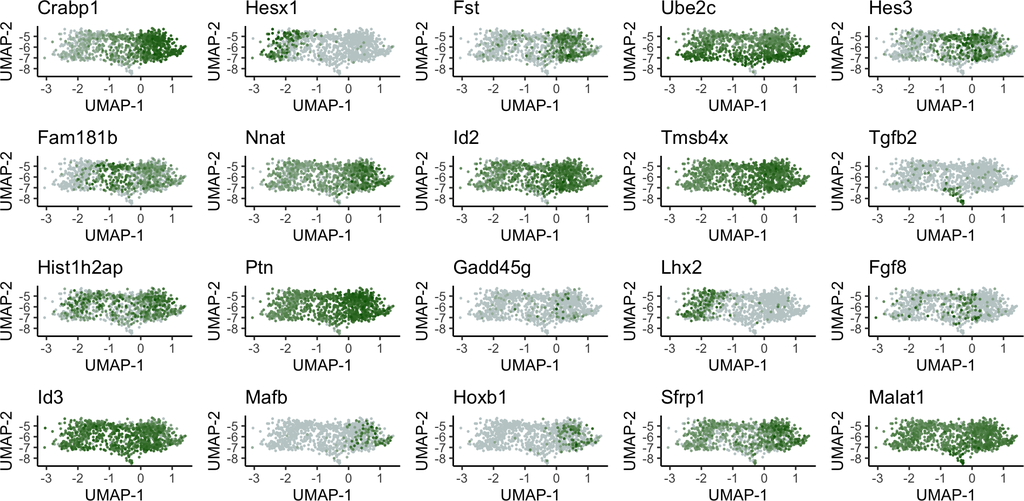

```r
p1 = plot_umaps_w_counts(sce_brain, genes_stat$gene)
p1
```

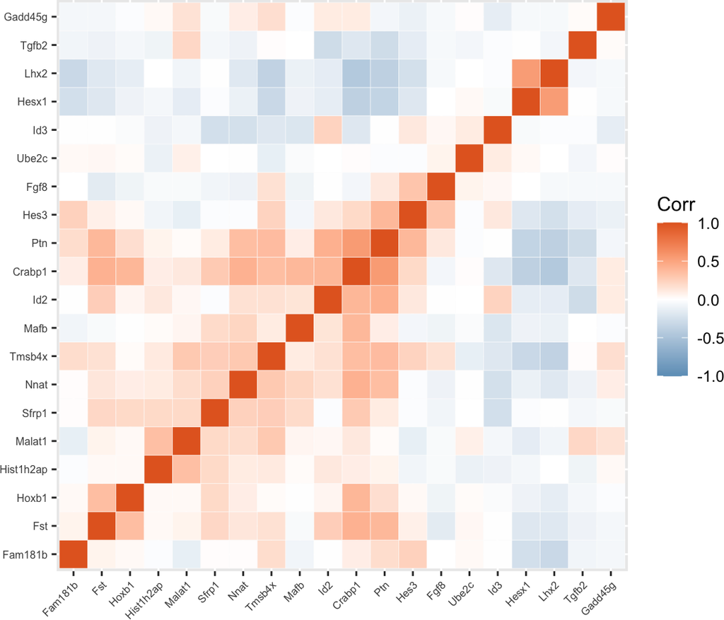

```r
p2 = plot_coexpression(sce_brain, genes_stat$gene)
p2
```

From manual annotation, we can conclude that we select both brain-specific genes that are either expressed in certain sub-regions (e.g. Hesx1, Fst, Mafb, etc) or expressed across most of the cells with different magnitude (e.g. Crabp1, Ptn, Nnat, etc) as well as non-brain specific genes that are relevant for cell state rather than cell type (e.g. Ube2c, Malat1, Hist1h2ap, etc).

Within 20 genes, we identify few genes / gene sets relevant for the sub-regions of the developing brain:

- **Prosencephalon** (Hesx1, Lhx2);
- **Mesencephalon** (Fam181b, Fgf8, Hes3);
- **Rhombencephalon** (Fst, Mafb, Hes3);
- **Tegmentum** (Tgfb2)

## 4.1 Using only genes DE in brain

A reasonable assumption is that a user wants to select only brain-related genes (and do not include cell state markers). This in principle can be done either post hoc or ad hoc.

If it is desired to minimize number of cell state genes ad hoc, we suggest to perform gene search on genes that are particularly relevant for brain development. As a proxy for this estimation, we will perform differential expression testings to select genes that are deferentially expressed in brain. This can be easily computed using `get_DE_genes` function. To note, this will also substantially reduce computation complexity.

Let’s plot UMAPs, colored by expression of the selected genes and co-expression plot.

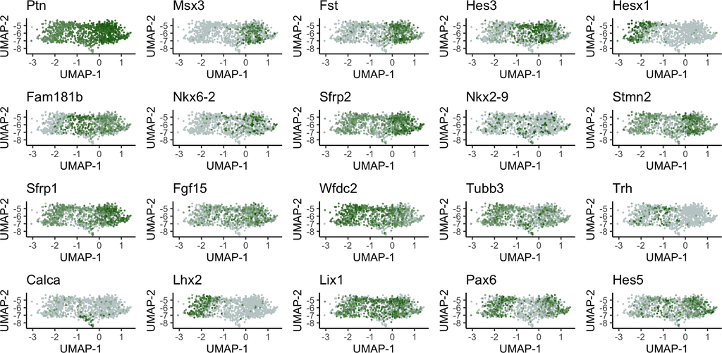

```r
markers = get_DE_genes(sce_mouseEmbryo , test.type = "binom", pval.type = "some")
genes_DE_brain = markers$gene[markers$celltype == celltype]
genes_stat = gene_search(sce_brain[genes_DE_brain,] , n_genes_total = n_genes_total, batch = "sample", verbose = F)

p1 = plot_umaps_w_counts(sce_brain, genes_stat$gene)
p1
```

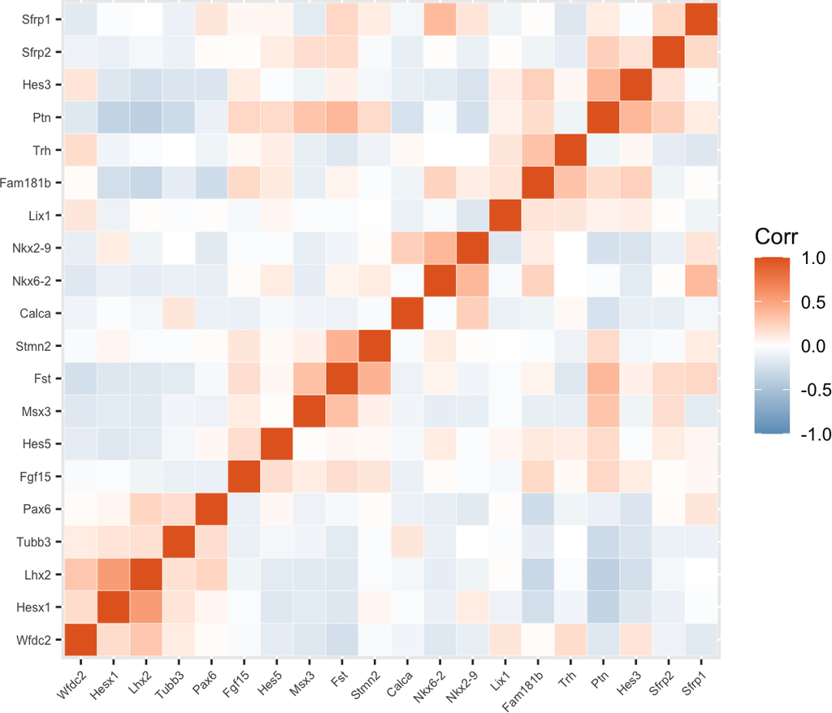

```r
p2 = plot_coexpression(sce_brain, genes_stat$gene)
p2
```

We conclude that we successfully resolves aforementioned brain sub-regions as well as discard cell state markers from the selection.

**Overall we suggest that `geneBasis` serves as an easy-to-implement and quick discovery tool to identify potential sources of variaibility within individual celltypes.**